# Practica 2 Tipologia y Ciclo de Vida de los Datos

# 4 Análisis de los datos

## 4.1 Selección de los grupos de datos que se quieren analizar o comparar

Todos conocemos la mítica frase “mujeres y niños primero” gracias a la película homónima, lo que no se decía tan claro en la película es que los ricos también iban primero. Está claro que una de las selecciones tiene que ser una división de supervivientes y fallecidos, la segunda tiene que ser por sexo y la tercera será por clase. Podríamos categorizar la edad para separar también por grupos, pero correríamos el riesgo de perder mucha información al establecer franjas de edad así que no lo vamos a hacer.

```r
titanic.primeraClase <- titanic[titanic$Pclass == 1,]
titanic.segundaClase <- titanic[titanic$Pclass == 2,]
titanic.terceraClase <- titanic[titanic$Pclass == 3,]

titanic.mujeres <- titanic[titanic$Sex == "female",]
titanic.hombres <- titanic[titanic$Sex == "male",]


titanic.supervivientes <- titanic[titanic$Survived == 1,]
titanic.fallecidos <- titanic[titanic$Survived == 0,]
```

## 4.2 Comprobación de la normalidad y homogeneidad de la varianza.

Vamos a comprobar la normalidad utilizando el test de shapiro-wilk. Este test consiste en un contraste de hipótesis en el que la hipótesis nula es la distribución normal de los datos.

```r
lapply(titanic[,c("Age", "SibSp", "Parch", "Fare")], shapiro.test)
```

```
## $Age
##
##  Shapiro-Wilk normality test
##
## data:  X[[i]]
## W = 0.98376, p-value = 2.181e-08
##
##
## $SibSp
##
##  Shapiro-Wilk normality test
##
## data:  X[[i]]
## W = 0.51297, p-value < 2.2e-16
##
##
## $Parch
##
##  Shapiro-Wilk normality test
##
## data:  X[[i]]
## W = 0.53281, p-value < 2.2e-16
##
##
## $Fare
##
##  Shapiro-Wilk normality test
##
## data:  X[[i]]
## W = 0.52214, p-value < 2.2e-16
```

Dado que en nuestro caso los valores p resultantes del análisis para todos los conjuntos numéricos es menor que 0.05, tenemos que rechazar la hipótesis nula y por tanto no se puede confirmar la normalidad de los datos.

El siguiente paso consistirá en el estudio de la homogeneidad de varianzas usando el test de Fligner-Killeen. En este caso, estudiaremos las diferencias en la varianza en los grupos de edad de los pasajeros que han fallecido y aquellos que lograron sobrevivir.

```r
fligner.test(Age ~ Survived, data = titanic)
```

```
##
##  Fligner-Killeen test of homogeneity of variances
##
## data:  Age by Survived
## Fligner-Killeen:med chi-squared = 3.7214, df = 1, p-value = 0.05372
```

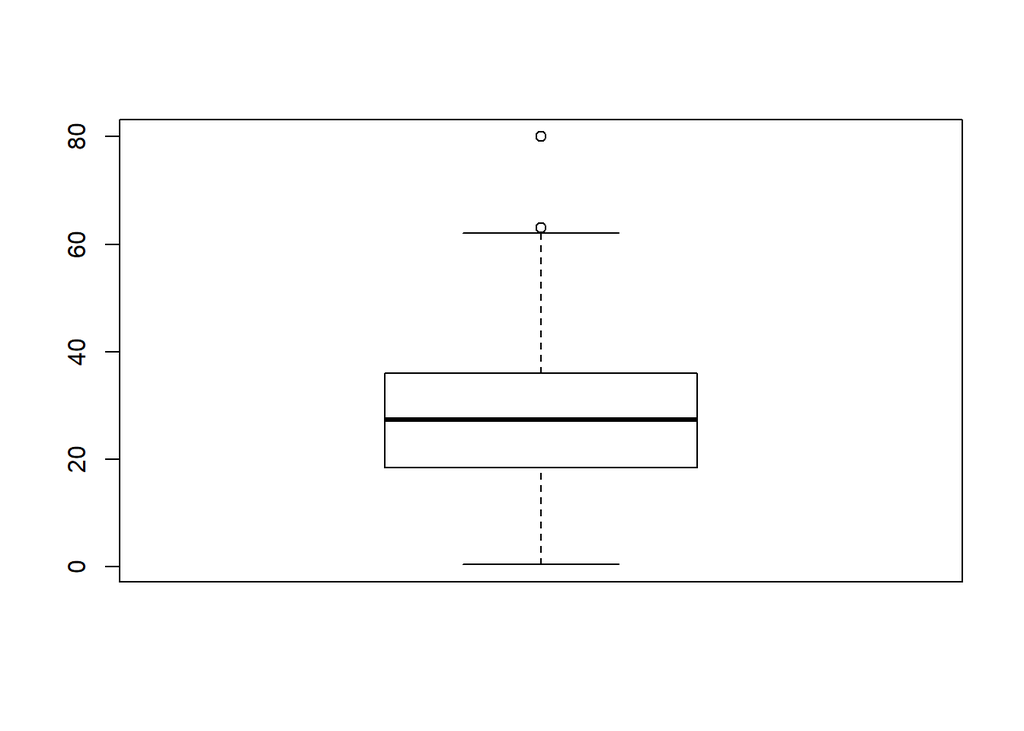

```r
boxplot(titanic.supervivientes[,"Age"])
```

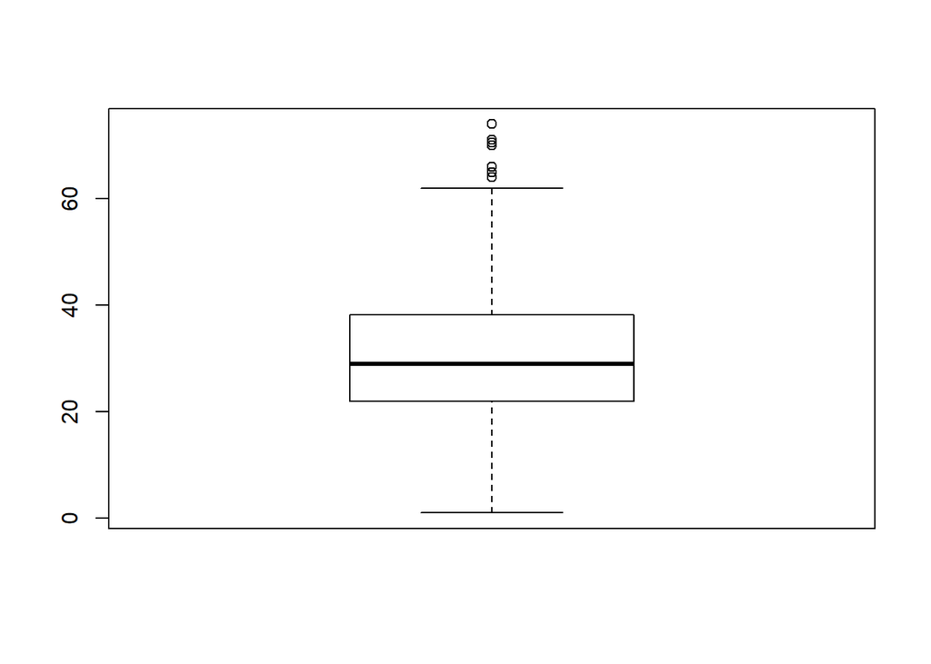

```r
boxplot(titanic.fallecidos[,"Age"])
```

Como decíamos, hubo un orden de evacuación claro definido según atributos de nuestro dataset, luego no estos resultados no nos extrañan. Veremos cuáles eran estos atributos en el siguiente apartado.

## 4.3 Aplicación de pruebas estadísticas para comparar los grupos de datos

### 4.3.1 Estudio de variables significativas

En primer lugar, estudiaremos las variables más significaivas a la hora de las posibilidades de supervivencia de los pasajeros. Para ello, usaremos un modelo de regresión logística que estime la probabilidad de superivencia frente a todas las variables disponibles.

```r
modelo.Surv <- glm(Survived ~ Pclass + Sex + SibSp + Parch + Fare + Age +  Embarked, data = titanic, family = "binomial"(link=logit))
summary(modelo.Surv)
```

```
##
## Call:
## glm(formula = Survived ~ Pclass + Sex + SibSp + Parch + Fare +
##     Age + Embarked, family = binomial(link = logit), data = titanic)
##
## Deviance Residuals:
##     Min       1Q   Median       3Q      Max
## -2.7473  -0.5920  -0.3880   0.6148   2.5054
##
## Coefficients:
##               Estimate Std. Error z value Pr(>|z|)
## (Intercept)  4.3408357  0.4879548   8.896  < 2e-16 ***
## Pclass2     -1.2314412  0.3109947  -3.960 7.50e-05 ***
## Pclass3     -2.5137930  0.3168995  -7.932 2.15e-15 ***
## Sexmale     -2.6900074  0.2003346 -13.428  < 2e-16 ***
## SibSp       -0.3975693  0.1113550  -3.570 0.000357 ***
## Parch       -0.0866171  0.1207172  -0.718 0.473053
## Fare         0.0005269  0.0023487   0.224 0.822493
## Age         -0.0496769  0.0082006  -6.058 1.38e-09 ***
## EmbarkedC    0.3698253  0.2397831   1.542 0.122993
## ---
## Signif. codes:  0 '***' 0.001 '**' 0.01 '*' 0.05 '.' 0.1 ' ' 1
##
## (Dispersion parameter for binomial family taken to be 1)
##
##     Null deviance: 1186.66  on 890  degrees of freedom
## Residual deviance:  772.16  on 882  degrees of freedom
## AIC: 790.16
##
## Number of Fisher Scoring iterations: 5
```

Comenzando por los resultados esperables, se observa que el hecho de ser de clase 1 o clase 3 influía fuertemente en tus posibilidades de supervivencia y que lo siguiente que más afectaba eran el sexo y la edad. De hecho, según los resultados, el hecho de ser mujer respecto a ser hombre influía casi lo mismo que la pertenencia a primera clase (obviamente la comparación no es exacta y cada individuo posee una combinación de características). Esto viene a confirmar lo mencionado anteriormente: Mujeres y niños (y ricos) primero.

Lo que nos ha sorprendido un poco por la precisión que muestra es la comparación entre el resultado de Parch y SibSp. El tamaño de la familia no resulta relevante en cuanto si un pasajero se salvaba o no ¡en cambio sí que lo supone el número de hermanos! Parece una medida incongruente, pero posiblemente no está hablando de que las familias grandes no tienen por qué ser jóvenes (recordemos el caso de Thomas Cardoza viajando con su madre), en cambio tener muchos hermanos sí que nos puede hablar de edades tempranas y por tanto de mayores posibilidades de salvación.

Vamos a comprobar si efectivamente a mayor número de hermanos menor era el rango de edad.

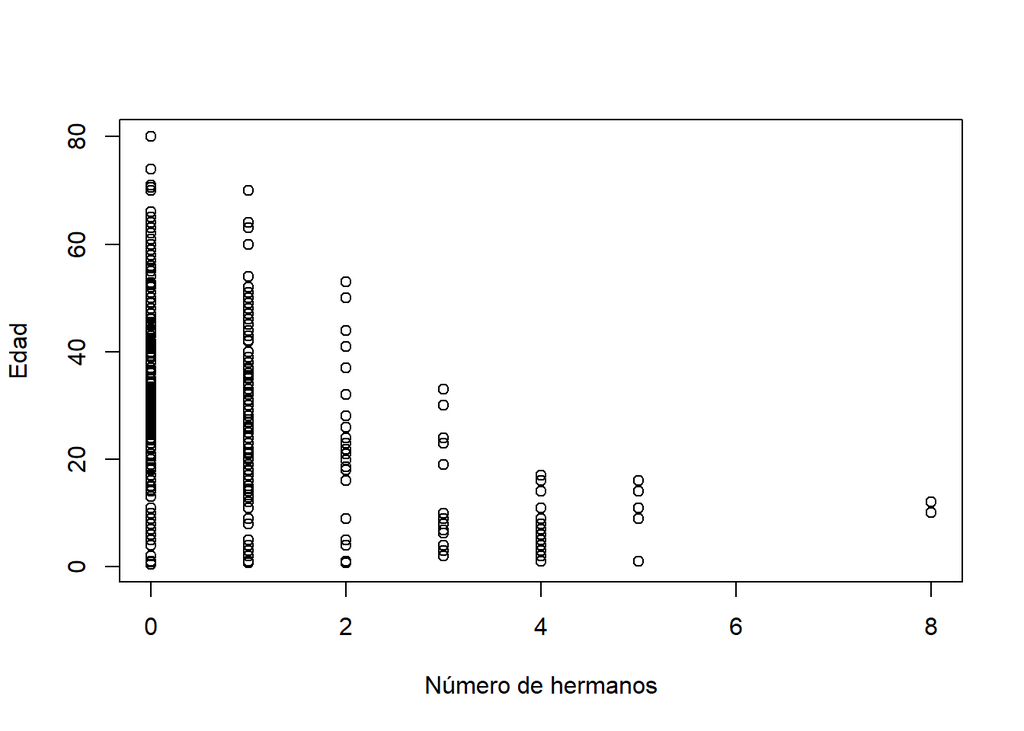

```r
plot(titanic$SibSp, titanic$Age,
     xlab="Número de hermanos",
     ylab="Edad")
```

Como curiosidad también nos gustaría comprobar la influencia del sexo y edad en la posibilidad de supervivencia, donde calcularemos la probabilidad de que sobrevivan 4 pasajeros: 2 hombres de edades 15 y 50, y 2 mujeres de la misma edad. Los vamos a introducir a todos en primera clase dado que esto nos permitirá aumentar las posibilidades de salvación de todos ellos y observar mejor las diferencias entre estos grupos.

```r
test <- data.frame( Pclass= c("1","1","1","1"),
                    Sex = c("female","male","female","male"),
                    SibSp = c(3,3,3,3),
                    Parch = c(1,1,1,1),
                    Fare = c(200,200,200,200),
                    Age = c(15,15,50,50),
                    Embarked = c("C","C","C","C")
                    )

predict(modelo.Surv, test, type = "response")
```

```
##         1         2         3         4
## 0.9422181 0.5253668 0.7413258 0.1628551
```

Se puede observar la gran influencia que tanto la edad como el sexo tienen sobre la posibilidad de sobrevivir, pero el rango en el que esto varía dentro de la primera clase es impresionante.

### 4.3.2 Estudio de la relación de Survived con Age, Sex y Pclass

Para terminar el estudio de la relaciones entre variables, utilizaremos el test de chi-cuadrado para comprobar si la relación entre la variable Survived es estadísticamente significativa entre el sexo, clase y edad de los pasajeros.

```r
tabla.SurvPclass <- table(titanic$Survived, titanic$Pclass)
tabla.SurvSex <- table(titanic$Survived, titanic$Sex)

chisq.test(tabla.SurvPclass)
```

```
##
##  Pearson's Chi-squared test
##
## data:  tabla.SurvPclass
## X-squared = 102.89, df = 2, p-value < 2.2e-16
```

```r
chisq.test(tabla.SurvSex)
```

```
##
##  Pearson's Chi-squared test with Yates' continuity correction
##
## data:  tabla.SurvSex
## X-squared = 260.72, df = 1, p-value < 2.2e-16
```

```r
chisq.test(x =titanic$Survived, y = titanic$Age )
```

```
##
##  Pearson's Chi-squared test
##
## data:  titanic$Survived and titanic$Age
## X-squared = 269.07, df = 190, p-value = 0.00014
```

Puesto que obtenemos en todos los tests un valor p menor que el valor de signifiación (0,05), podemos rechazar la hipótesis nula y admitimos que dichas variables son estadisticamente significativas con la variable Survived.

### 4.3.3 ¿La proporción de pasajeros fallecidos de Clase 3 es realmente mayor que la proporción de pasajeros fallecidos de clase 1?

Siendo $p\textsubscript{c3}$ la proporción de pasajeros de clase 3 que no han sobrevivido y $p\textsubscript{c1}$ la proporción de pasajeros de clase 1 que no han sobrevivido.

```r
(numPrimera <- length(titanic.primeraClase$Survived))
```

```
## [1] 216
```

```r
(numTercera <- length(titanic.terceraClase$Survived))
```

```
## [1] 491
```

Para este caso, debido al teorema del limite central y que las dos muestras tienen un número alto de registros, se asumirá la normalidad de la distribución.

```r
(p1 <- sum(titanic.terceraClase$Survived == 0) / numTercera)
```

```
## [1] 0.7576375
```

```r
(p2 <- sum(titanic.primeraClase$Survived == 0) / numPrimera)
```

```
## [1] 0.3703704
```

```r
#Comprobación
success <- c(p1*numTercera,p2*numPrimera)
n <- c(numTercera,numPrimera)
prop.test( success, n, alternative="greater", correct=FALSE)
```

```
##
##  2-sample test for equality of proportions without continuity
##  correction
##
## data:  success out of n
## X-squared = 97.566, df = 1, p-value < 2.2e-16
## alternative hypothesis: greater
## 95 percent confidence interval:
##  0.3245555 1.0000000
## sample estimates:
##    prop 1    prop 2
## 0.7576375 0.3703704
```

Obtenemos un valor p menor que el nivel de significación (0,05) por lo que rechazamos la hipótesis nula y admitimos la hipótesis alternativa diciendo que efectivamente, la proporción de pasajeros fallecidos de Clase 3 es mayor que la proporción de pasajeros fallecidos de clase 1

# 5 Representación de los resultados a partir de tablas, gráficas y conclusiones finales.

En general nos hemos encontrado con un conjunto razonablemente limpio pero cuyos pocos problemas de limpieza eran complejos. La toma de decisiones respecto a imputar o no imputar un valor, respecto a qué considerar outlier o respecto a las estrategias de limpieza, pueden llegar a ser muy complejas y a necesitar de un conocimiento cualitativo del campo de aplicación muy alto.

Estamos bastante contentos con los resultados, hemos tratado problemas muy diversos y utilizado distintas técnicas de imputación. En el proceso también hemos ido extrayendo pequeñas conclusiones. Por ejemplo hemos podido encontrar dos tipologías de viaje en grupo: familia joven con muchos hermanos y familias mayores. A este respecto podemos complementar la gráfica anterior en la que observábamos que a mayor número de hermanos más pequeñas eran las edades de los individuos, con otra en la que veremos cómo eso no sucede con la cantidad de miembros en la familia, de hecho en este caso parece incluso converger hacia los 40 años de edad.

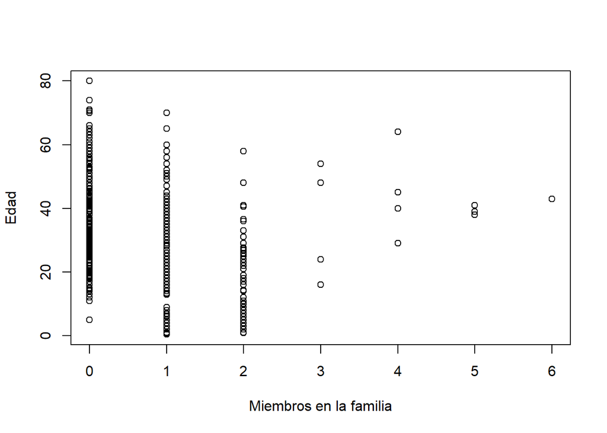

```r
plot(titanic$Parch, titanic$Age,
     xlab="Miembros en la familia",
     ylab="Edad")
```

Esta ha sido la mayor sorpresa que nos hemos encontrado durante el análisis, de hecho nos habría encantado poder indagar aún más en la composición de las diferentes familias a bordo del titanic mediante el estudio de las relaciones de parentesco entre pasajeros, una dimensión que desgraciadamente no se encontraba presente en este dataset.

Pero también hemos podido comprobar las conclusiones predecibles para este trabajo, estas son que la edad, el sexo y la clase social influyó altamente en las probabilidades de supervivencia. Podemos observar la interacción entre las dos primeras gracias al siguiente gráfico.

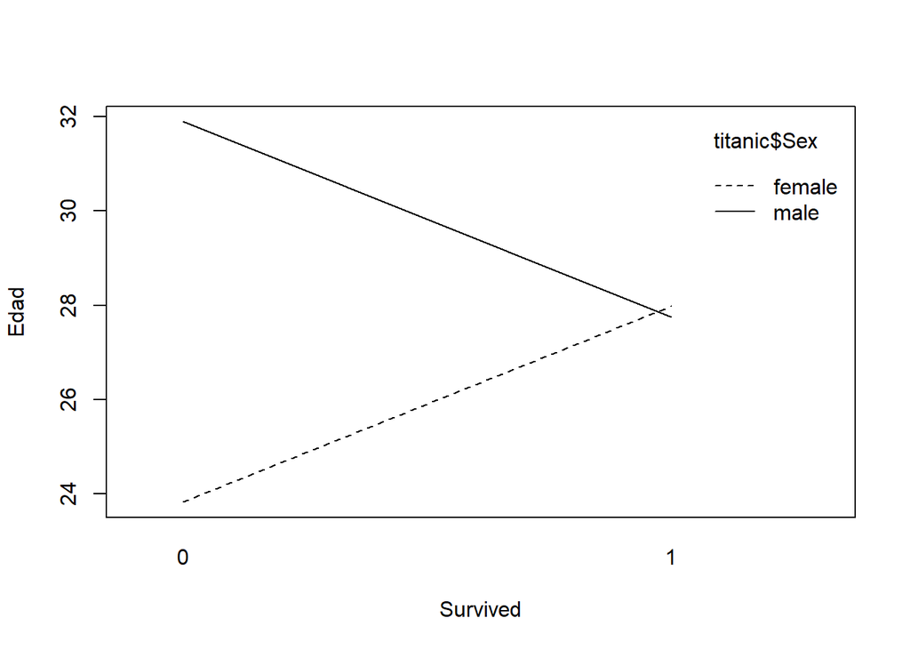

```r
interaction.plot(titanic$Survived,titanic$Sex,titanic$Age,
                 xlab = "Survived", ylab = "Edad")
```

A través del gráfico podemos ver como la edad media de las mujeres que fallecieron es mucho menor que la edad media de los hombres que fallecieron. No obstante, es curioso observar que la edad media de aquellos hombres que lograron sobrevivir es menor que la edad media de aquellas mujeres que también sobrevivieron, probablemente reducida sobremanera dado que los hombres que se salvaron fueron en su mayoría niños.

Por último, podemos observar de otra forma a las ya realizadas qué variables separan mejor nuestros datos para poder clasificar si han sobrevivido o no. Ya mencionábamos al comienzo del trabajo que este dataset era muy utilizado para generar árboles de clasificación, así que realizaremos el de rigor mediante el paquete rpart y procederemos a explicar las conclusiones que de él se derivan.

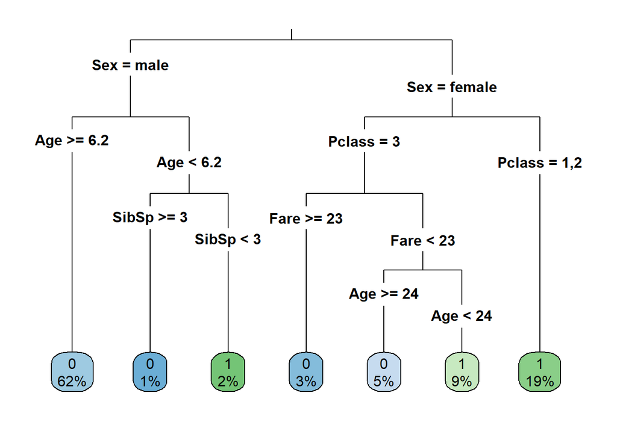

```r
supervivencia <- rpart(Survived~.,data=titanic,method="class",
                        minsplit=1,cp=.02,parms = list(split ="gini"))

rpart.plot(supervivencia,type = 3,extra = 100 ,clip.right.lab = FALSE)
```

Una vez más y de otra forma diferente, llegamos a la conclusión de que las variables más significativas a la hora de detectar si el pasajero ha sobrevivido o no son el sexo, la edad y la clase en la que el pasajero viajaba.

No hemos dejado de discutir durante el proceso de escritura a qué se podría deber este orden de prioridad. Está claro que la clase podía influir de muchas formas diferentes: Estos pasajeros viajaban más cerca de la cubierta y tenían mejor acceso a los botes salvavidas, pero sin duda pudo tomar parte un factor inconsciente por parte de la tripulación que los considerara más “merecedores” de ser salvados, de hecho esta circunstancia en ningún momento fue explícita. Por otra parte resulta curioso qué definió la prelación “mujeres y niños primero”, no compete a este trabajo determinar dicha decisión, pero hoy en día sería tremendamente cuestionable. No podemos olvidar que el titanic se hundió en 1912, y que las condiciones socio-políticas de la época difieren de las actuales sobremanera.

# 6 Exportación del dataset

```r
str(titanic)
```

```
## 'data.frame':    891 obs. of  8 variables:
##  $ Survived: Factor w/ 2 levels "0","1": 1 2 2 2 1 1 1 1 2 2 ...
##  $ Pclass  : Factor w/ 3 levels "1","2","3": 3 1 3 1 3 3 1 3 3 2 ...
##  $ Sex     : Factor w/ 2 levels "female","male": 2 1 1 1 2 2 2 2 1 1 ...
##  $ Age     : num  22 38 26 35 35 ...
##  $ SibSp   : int  1 1 0 1 0 0 0 3 0 1 ...
##  $ Parch   : int  0 0 0 0 0 0 0 1 2 0 ...
##  $ Fare    : num  7.25 71.28 7.92 53.1 8.05 ...
##  $ Embarked: Factor w/ 3 levels "S","C","Q": 1 2 1 1 1 1 1 1 1 2 ...
```

```r
titanic_raw$Survived <- titanic$Survived
titanic_raw$Pclass   <- titanic$Pclass
titanic_raw$Sex      <- titanic$Sex
titanic_raw$Age      <- titanic$Age
titanic_raw$SibSp    <- titanic$SibSp
titanic_raw$Parch    <- titanic$Parch
titanic_raw$Fare     <- titanic$Fare
titanic_raw$Embarked <- titanic$Embarked

write.csv(titanic_raw,"./csv/Titanic_clean.csv",
          row.names=FALSE, fileEncoding = 'UTF-8')
```